# Bank Data Analytics

# The most Common columns are:

- duration
- month
- campaign
- balance
- pdays

```python
X=X_resampled[['duration','month','campaign','balance','pdays']]
```

```python
X.shape,y_resampled.shape
```

```
((79844, 5), (79844,))
```

```python
from sklearn.model_selection import train_test_split
X_train,X_test,y_train,y_test=train_test_split(X,y_resampled,test_size=0.2,random_state=42,stratify=y_resampled)
```

```python
from sklearn.naive_bayes import GaussianNB
from sklearn.linear_model import LogisticRegression
from sklearn.tree import DecisionTreeClassifier
from sklearn.ensemble import RandomForestClassifier, AdaBoostClassifier
from sklearn.naive_bayes import GaussianNB
from sklearn.model_selection import GridSearchCV
import numpy as np
from sklearn.neighbors import KNeighborsClassifier

models_and_params = {
    'LogisticRegression': {
        'model': LogisticRegression(max_iter=1000),
        'params': {
            'C': [0.01, 0.1, 1, 10],  # Regularization strength
        }
    },
    'DecisionTreeClassifier': {
        'model': DecisionTreeClassifier(),
        'params': {
            'max_depth': [None, 5, 10, 20],  # Controls model complexity
            'criterion': ['gini', 'entropy']
        }
    },
    'RandomForestClassifier': {
        'model': RandomForestClassifier(),
        'params': {
            'n_estimators': [50, 100],      # Number of trees
            'max_depth': [None, 10, 20],    # Depth of each tree
        }
    },
    'GaussianNB': {
        'model': GaussianNB(),
        'params': {
           'var_smoothing':[1e-09]
        }
    },
    'KNeighborsClassifier': {
        'model': KNeighborsClassifier(),
        'params': {
            'n_neighbors': [3, 5, 7, 9],        # Number of neighbors
            'weights': ['uniform', 'distance'], # Voting method
            'p': [1, 2]                          # Distance metric (1: Manhattan, 2: Euclidean)
        }
    }
}
```

```python
def tune_models_return_best_only(X, y, models_and_params, cv=5, scoring='accuracy'):
    best_models={}
    for name, mp in models_and_params.items():
        print(f"Tuning {name}...")
        grid = GridSearchCV(mp['model'], mp['params'], cv=cv, scoring=scoring)
        grid.fit(X, y)
        print(f"Best score for {name}: {grid.best_score_:.4f}")
        print(f'Best Parametes for {name} is {grid.best_params_}')
        best_models[name]=grid.best_estimator_
    return best_models
```

```python
best_models=tune_models_return_best_only(X_train,y_train,models_and_params)
```

```
Tuning LogisticRegression...
Best score for LogisticRegression: 0.7534
Best Parametes for LogisticRegression is {'C': 10}
Tuning DecisionTreeClassifier...
Best score for DecisionTreeClassifier: 0.8655
Best Parametes for DecisionTreeClassifier is {'criterion': 'entropy', 'max_depth': 20}
Tuning RandomForestClassifier...
Best score for RandomForestClassifier: 0.8954
Best Parametes for RandomForestClassifier is {'max_depth': 20, 'n_estimators': 100}
Tuning GaussianNB...
Best score for GaussianNB: 0.7427
Best Parametes for GaussianNB is {'var_smoothing': 1e-09}
Tuning KNeighborsClassifier...
Best score for KNeighborsClassifier: 0.8707
Best Parametes for KNeighborsClassifier is {'n_neighbors': 9, 'p': 1, 'weights': 'distance'}
```

```python
best_models
```

```
{'LogisticRegression': LogisticRegression(C=10, max_iter=1000),
 'DecisionTreeClassifier': DecisionTreeClassifier(criterion='entropy', max_depth=20),
 'RandomForestClassifier': RandomForestClassifier(max_depth=20),
 'GaussianNB': GaussianNB(),
 'KNeighborsClassifier': KNeighborsClassifier(n_neighbors=9, p=1, weights='distance')}
```

```python
import warnings # ignore un-necessary warnings
warnings.filterwarnings('ignore')
```

```python
from sklearn.metrics import confusion_matrix,accuracy_score,precision_score,recall_score,f1_score,roc_curve,roc_auc_score,confusion_matrix,classification_report
def performance(best_models,X_test,y_test):
    for name,model in best_models.items():
        print('*'*20,name,'*'*20)
        y_predict=model.predict(X_test)
        print("Accuracy Score:",accuracy_score(y_test,y_predict))
        print("Confusion Matrix\n",confusion_matrix(y_test,y_predict))
        print('Classification Report:\n',classification_report(y_test,y_predict))
```

```python
performance(best_models,X_test,y_test)
```

```
******************** LogisticRegression ********************
Accuracy Score: 0.7592836119982466
Confusion Matrix
 [[6453 1532]
 [2312 5672]]
Classification Report:
               precision    recall  f1-score   support

          no       0.74      0.81      0.77      7985
         yes       0.79      0.71      0.75      7984

    accuracy                           0.76     15969
   macro avg       0.76      0.76      0.76     15969
weighted avg       0.76      0.76      0.76     15969

******************** DecisionTreeClassifier ********************
Accuracy Score: 0.8693719080718892
Confusion Matrix
 [[6907 1078]
 [1008 6976]]
Classification Report:
               precision    recall  f1-score   support

          no       0.87      0.86      0.87      7985
         yes       0.87      0.87      0.87      7984

    accuracy                           0.87     15969
   macro avg       0.87      0.87      0.87     15969
weighted avg       0.87      0.87      0.87     15969

******************** RandomForestClassifier ********************
Accuracy Score: 0.8997432525518192
Confusion Matrix
 [[7067  918]
 [ 683 7301]]
Classification Report:
               precision    recall  f1-score   support

          no       0.91      0.89      0.90      7985
         yes       0.89      0.91      0.90      7984
```

[output cut: 19 more lines]

```

******************** KNeighborsClassifier ********************
Accuracy Score: 0.8750078276661031
Confusion Matrix
 [[6841 1144]
 [ 852 7132]]
Classification Report:
               precision    recall  f1-score   support

          no       0.89      0.86      0.87      7985
         yes       0.86      0.89      0.88      7984

    accuracy                           0.88     15969
   macro avg       0.88      0.88      0.87     15969
weighted avg       0.88      0.88      0.87     15969
```

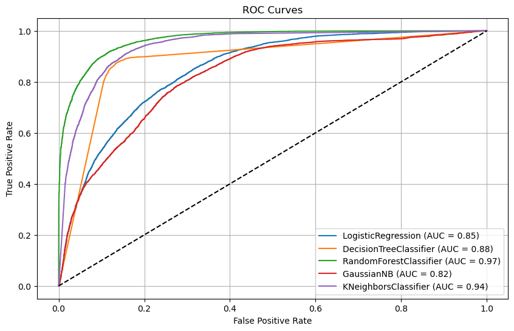

```python
import matplotlib.pyplot as plt
from sklearn.metrics import roc_curve, roc_auc_score
import pandas as pd
import numpy as np

# Assume y_test contains labels like 'yes' and 'no'
# Convert y_test to binary: 'yes' -> 1, 'no' -> 0
y_test_binary = (y_test == 'yes').astype(int)

# Plot ROC curves for each model
plt.figure(figsize=(10, 6))

for name, model in best_models.items():
    # Predict probabilities for the positive class
    y_prob = model.predict_proba(X_test)[:, 1]

    # Compute False Positive Rate and True Positive Rate
    fpr, tpr, _ = roc_curve(y_test_binary, y_prob)

    # Compute Area Under the Curve
    auc = roc_auc_score(y_test_binary, y_prob)

    # Plot the ROC curve
    plt.plot(fpr, tpr, label=f"{name} (AUC = {auc:.2f})")

# Diagonal reference line
plt.plot([0, 1], [0, 1], 'k--')

# Plot settings
plt.title("ROC Curves")
plt.xlabel("False Positive Rate")
plt.ylabel("True Positive Rate")
plt.legend()
plt.grid(True)
plt.show()
```

# 📊 Model Comparison and Performance Analysis

## 🔹 1. Logistic Regression

- **Accuracy**: 0.76
- **Precision**:
  - No: 0.74
  - Yes: 0.79
- **Recall**:
  - No: 0.81
  - Yes: 0.71
- **F1-Score**:
  - No: 0.77
  - Yes: 0.75

**🧠 Insights:**

- Performs moderately well with a slight bias toward predicting the "no" class (higher recall).
- Lower recall on "yes" indicates some false negatives.
- A good **baseline model**, but other models outperform it significantly.

## 🔹 2. Decision Tree Classifier

- **Accuracy**: 0.87
- **Precision & Recall**: ~0.87 for both classes
- **F1-Score**: 0.87 for both classes

**🧠 Insights:**

- Strong and **balanced performance** for both classes.
- Easily interpretable and fast.

## 🔹 3. Random Forest Classifier

- **Accuracy**: **0.90** (Highest)
- **Precision**:
  - No: 0.91
  - Yes: 0.89
- **Recall**:
  - No: 0.89
  - Yes: 0.91
- **F1-Score**: 0.90 for both classes

**🧠 Insights:**

- **Best performing model** overall.
- High precision and recall → well-balanced classifier.
- Less prone to overfitting compared to single trees due to the ensemble method.
- Suitable for **production-level deployment**.

## 🔹 4. Gaussian Naive Bayes

- **Accuracy**: 0.75
- **Precision & Recall**: ~0.74–0.76
- **F1-Score**: 0.75

**🧠 Insights:**

- Performs similarly to Logistic Regression but slightly worse overall.
- Assumes **feature independence**, which may not hold in practice.
- Lightweight and fast, but **not suitable** for complex data dependencies.

## 🔹 5. K-Nearest Neighbors (KNN)

- **Accuracy**: 0.875
- **Precision**:
  - No: 0.89
  - Yes: 0.86
- **Recall**:
  - No: 0.86
  - Yes: 0.89
- **F1-Score**: ~0.87–0.88

**🧠 Insights:**

- Performs **very well**, second only to Random Forest.
- Good at capturing **non-linear patterns**, but performance depends heavily on `k`.

# Conclusion:

- The **Random Forest Classifier** performs the best from others with **AUC=0.97**
- The **KNN with AUC=0.94** and next **Decision Tree Classifier with AUC=0.88**

# Save the Model

```python
joblib(best_models['RandomForestClassifier'],'RandomForestClassifier_model.pkl')
```